# Data Handling: Import, Cleaning and Visualization

## Updates

## Recap

## Cleaning and analytics

1. Stacking
2. Merging (joining) datasets
3. Data manipulation with `tidyverse()`
4. Aggregation of statistics

## Merging (joining) datasets: R

Overview by Wickham and Grolemund (2017):

| dplyr (tidyverse) | base::merge |
| --- | --- |
| `inner_join(x, y)` | `merge(x, y)` |
| `left_join(x, y)` | `merge(x, y, all.x = TRUE)` |
| `right_join(x, y)` | `merge(x, y, all.y = TRUE)`, |
| `full_join(x, y)` | `merge(x, y, all = TRUE)` |

## Data manipulation

- `arrange()`
- `select()`
- `filter()`
- `mutate()`
- `group_by()`
- `summarize()`

## Warm up and test LockDown browser

[figure not shown]

## Warm up and test LockDown browser

On Canvas, open the survey “LockDown browser test”. Answer the questions.

*You must install the LockDown browser on your computer*

## Joining

Consider the following code:

```r
temperature_conversions <- data.frame(conversion_factor = c(5/9, 1),
                                      scale = c("Fahrenheit", "Celsius"))

temperature <- data.frame(city = c("StGallen", "Zürich", "Detroit"),
                          temp = c(12, 14, 21),
                          scale = c("Cel", "Cel", "F"))
```

Select statements that are true:

- `inner_join(temperature, temperature_conversions, by="scale")` returns a data frame with 3 rows.
- `left_join(temperature, temperature_conversions, by="scale")` returns a data frame with 3 rows.
- `full_join(temperature, temperature_conversions, by="scale")` returns a data frame with 3 rows.

## Data manipulation

Consider the following data frame:

```
> main_dataset
      city temp      scale conversion_factor
1 StGallen   12    Celsius         1.0000000
2   Zürich   14    Celsius         1.0000000
3  Detroit   40 Fahrenheit         0.5555556
```

Select statements that are true:

- `main_dataset |> mutate(temp_celsius = ifelse(scale == "Fahrenheit", (temp-32) * conversion_factor, temp))` replaces the variable `temp` with `temp_celsius`
- `main_dataset |> mutate(temp_celsius = ifelse(scale == "Fahrenheit", (temp-32) * conversion_factor, temp))` has 3 rows and 5 columns
- `main_dataset |> summarize(mean_temp = mean(temp), min_temp = min(temp))` returns a tibble containing 2 columns and 1 row
- `main_dataset |> summarize(mean_scale = mean(scale), sd_scale = sd(scale))` is a good way to get summary statistics about the variable `scale`

## Stacking: True or False

Consider the following code:

```r
Ostschwiz <- data.frame(
  Region = c("St. Gallen", "Appenzell", "Appenzell"),
  FavoriteBeverage = c("Schützengarten", "Quöllfrisch", "Appenzeller"),
  Year = c(2021, 2021, 2022)
)

Valais <- data.frame(
  Region = c("Valais"),
  FavoriteBeverage = c("Fendant"),
  Year = c(2021)
)

Vaud <- data.frame(
  Region = c("Vaud"),
  FavoriteBeverage = c("Chasselas"),
  Year = c(2021)
)
```

The statement `nrow(rbind(Ostschwiz, Valais, Vaud)) == 5` returns `FALSE`

## Stacking and reshaping: True or False

Consider the following data frame

```r
Ostschwiz <- data.frame(
  Region = c("St. Gallen", "Appenzell", "Appenzell"),
  FavoriteBeverage = c("Schützengarten", "Quöllfrisch", "Appenzeller"),
  Year = c(2021, 2021, 2022)
)

Valais <- data.frame(
  Region = c("Valais"),
  FavoriteBeverage = c("Fendant"),
  Year = c(2021)
)

Vaud <- data.frame(
  Region = c("Vaud"),
  FavoriteBeverage = c("Chasselas"),
  Year = c(2021)
)

Ostschwiz <- pivot_wider(Ostschwiz,
                         names_from = c(Year),
                         values_from = FavoriteBeverage)
```

The statement `colnames(Ostschwiz)[2]` returns `"FavoriteBeverage`

## Data visualization

## Data visualization

- Final step of data pipeline/data science procedure!
  - Convincingly communicating insights from data.
  - Data visualization is all about *telling a story*.
- *R* is a very powerful tool to do this!

## Data visualization

- Data visualization is *THE* most important part of delivering results!
- Best way to convince people about your message (and about your competence 🎓)

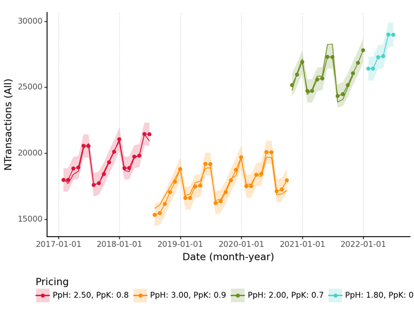

## Data visualization

Two ways: display data through *tables* or *graphs*.

Depends on the purpose.

## Data visualization

- A *chart* typically contains at least one axis, the **values are represented in terms of visual objects** (dots, lines, bars) and axes typically have scales or labels.
  - If we are interested in exploring, analyzing or communicating *patterns* in the data, *charts are more useful than tables*.
- A *table* typically contains rows and columns, and the **values are represented by text**.
  - If we are interested in exploring, analyzing or communicating *specific numbers* in the data, *tables are more useful than graphs*.

## Tables

## Tables

- Formatting data values for publication.
- Typical: String operations to make numbers and text look nicer.
  - Before creating a table or figure…

## Tables

```r
# load packages and data
library(tidyverse)
data("swiss")

# compute summary statistics
swiss_summary <- swiss |>
  summarise(avg_education = mean(Education),
            avg_fertility = mean(Fertility),
            N = n()
  )

swiss_summary
```

```
##   avg_education avg_fertility  N
## 1      10.97872      70.14255 47
```

*Problems?*

## Tables: round numeric values

```r
swiss_summary_rounded <- round(swiss_summary, 2)
swiss_summary_rounded
```

```
##   avg_education avg_fertility  N
## 1         10.98         70.14 47
```

## Tables: detailed formatting of numbers

- Coerce to text.
- String operations.
- Decimal marks, units (e.g., currencies), other special characters for special formats (e.g. coordinates).
- *`format()`*-function

## Tables: `format()` example

```r
swiss_form <- format(swiss_summary_rounded,
                     decimal.mark = ",")
swiss_form
```

```
##   avg_education avg_fertility  N
## 1         10,98         70,14 47
```

## See also the helpful functions for formatting text-strings

- Uppercase/lowercase: `toupper()`/`tolower()`.
- Remove white spaces: `trimws()`,

```r
string <- "AbCD "
toupper(string)
```

```
## [1] "ABCD "
```

```r
tolower(string)
```

```
## [1] "abcd "
```

```r
trimws(tolower(string))
```

```
## [1] "abcd"
```

## Get creative with tables: `gtExtras` and sparklines

```r
head(USArrests, 10)
```

```
##             Murder Assault UrbanPop Rape
## Alabama       13.2     236       58 21.2
## Alaska        10.0     263       48 44.5
## Arizona        8.1     294       80 31.0
## Arkansas       8.8     190       50 19.5
## California     9.0     276       91 40.6
## Colorado       7.9     204       78 38.7
## Connecticut    3.3     110       77 11.1
## Delaware       5.9     238       72 15.8
## Florida       15.4     335       80 31.9
## Georgia       17.4     211       60 25.8
```

*Problems?*

## Get creative with tables: `gtExtras` and sparklines

```r
library(gtExtras)

USArrests_summary <- USArrests |>
  mutate(UrbanPop = case_when(UrbanPop > quantile(UrbanPop, .66) ~ "High",
                                UrbanPop > quantile(UrbanPop, .33) ~ "Middle",
                                UrbanPop > 0 ~ "Low")) |>
  group_by(UrbanPop) |>
  summarize(
    "Mean murder" = mean(Murder),
    "SD murder" = sd(Murder),
    Density = list(Murder),
    .groups = "drop"
  )
```

## Get creative with tables: `gtExtras` and sparklines

```r
USArrests_summary |>
  gt() |>
  tab_header(
    title = md("Murder rates"),
    subtitle = md("Per high, middle, and low urban population ")
  ) |>
  gtExtras::gt_plt_dist(Density, type = "density", line_color = "black",
                         fill_color = "red") %>%
  fmt_number(columns = `Mean murder`:`SD murder`, decimals = 2)
```

Murder rates

Per high, middle, and low urban population

| UrbanPop | Mean murder | SD murder | Density |
| --- | --- | --- | --- |
| High | 8.07 | 3.80 |  |
| Low | 7.41 | 5.20 |  |
| Middle | 7.89 | 4.18 |  |

## Get creative with tables: other sources

- `kable()` for `html` / Markdown reports
- `stargazer` for your LaTeX reports or for your Office Word reports

## Get creative with tables: `kable()`

```r
knitr::kable(head(USArrests, 5), format = "markdown")
```

|  | Murder | Assault | UrbanPop | Rape |
| --- | --- | --- | --- | --- |
| Alabama | 13.2 | 236 | 58 | 21.2 |
| Alaska | 10.0 | 263 | 48 | 44.5 |
| Arizona | 8.1 | 294 | 80 | 31.0 |
| Arkansas | 8.8 | 190 | 50 | 19.5 |
| California | 9.0 | 276 | 91 | 40.6 |

## Get creative with tables: `kable()`

```r
knitr::kable(head(USArrests, 5), format = "html")
```

|  | Murder | Assault | UrbanPop | Rape |
| --- | --- | --- | --- | --- |
| Alabama | 13.2 | 236 | 58 | 21.2 |
| Alaska | 10.0 | 263 | 48 | 44.5 |
| Arizona | 8.1 | 294 | 80 | 31.0 |
| Arkansas | 8.8 | 190 | 50 | 19.5 |
| California | 9.0 | 276 | 91 | 40.6 |

## Graphs with R (ggplot2)

## Graphs with R

Three main approaches:

1. The original `graphics` package ((R Core Team 2018); shipped with the base R installation).

## Graphs with R

Three main approaches:

1. The original `graphics` package ((R Core Team 2018); shipped with the base R installation).
2. The `lattice` package (Sarkar 2008), an implementation of the original Bell Labs ‘Trellis’ system.

## Graphs with R

Three main approaches:

1. The original `graphics` package ((R Core Team 2018); shipped with the base R installation).
2. The `lattice` package (Sarkar 2008), an implementation of the original Bell Labs ‘Trellis’ system.
3. The *`ggplot2`* package (Wickham 2016), an implementation of Leland Wilkinson’s ‘Grammar of Graphics’.

## Graphs with R

Three main approaches:

1. The original `graphics` package ((R Core Team 2018); shipped with the base R installation).
2. The `lattice` package (Sarkar 2008), an implementation of the original Bell Labs ‘Trellis’ system.
3. The *`ggplot2`* package (Wickham 2016), an implementation of Leland Wilkinson’s ‘Grammar of Graphics’.

`ggplot2` is so good that it has become *THE* reference [In python, use `plotnine` to apply the grammar of graphics.]

## Grammar of graphics

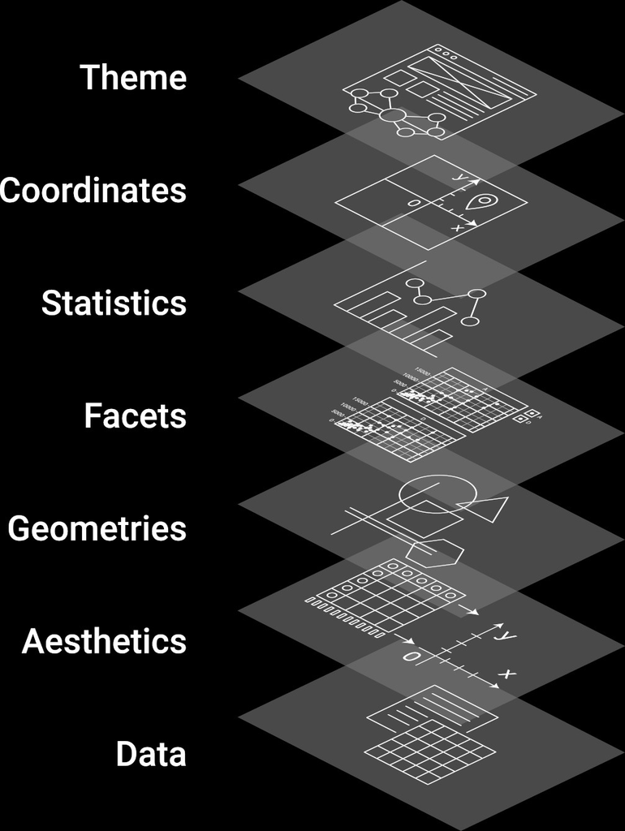

## `ggplot2`

## `ggplot2` basics

Using `ggplot2` to generate a basic plot in R is quite simple. Basically, it involves three key points:

1. The data must be stored in a `data.frame`/`tibble` (in tidy format!).

## `ggplot2` basics

Using `ggplot2` to generate a basic plot in R is quite simple. Basically, it involves three key points:

1. The data must be stored in a `data.frame`/`tibble` (in tidy format!).
2. The starting point of a plot is always the function `ggplot()`.

## `ggplot2` basics

Using `ggplot2` to generate a basic plot in R is quite simple. Basically, it involves three key points:

1. The data must be stored in a `data.frame`/`tibble` (in tidy format!).
2. The starting point of a plot is always the function `ggplot()`.
3. The first line of plot code declares the data and the ‘aesthetics’ (e.g., which variables are mapped to the x-/y-axes):

## `ggplot2` basics

Using `ggplot2` to generate a basic plot in R is quite simple. Basically, it involves three key points:

1. The data must be stored in a `data.frame`/`tibble` (in tidy format!).
2. The starting point of a plot is always the function `ggplot()`.
3. The first line of plot code declares the data and the ‘aesthetics’ (e.g., which variables are mapped to the x-/y-axes):

```r
ggplot(data = my_dataframe, aes(x= xvar, y= yvar))
```

## Example data set: `swiss`

```r
library(tidyverse) # automatically loads ggplot2

# load the data
data(swiss)
head(swiss)
```

```
##              Fertility Agriculture Examination Education Catholic Infant.Mortality
## Courtelary        80.2        17.0          15        12     9.96             22.2
## Delemont          83.1        45.1           6         9    84.84             22.2
## Franches-Mnt      92.5        39.7           5         5    93.40             20.2
## Moutier           85.8        36.5          12         7    33.77             20.3
## Neuveville        76.9        43.5          17        15     5.16             20.6
## Porrentruy        76.1        35.3           9         7    90.57             26.6
```

## Add indicator variable

Code a province as ‘Catholic’ if more than 50% of the inhabitants are catholic:

```r
# via tidyverse/mutate
swiss <- mutate(swiss,
                Religion =
                  ifelse(50 < Catholic, 'Catholic', 'Protestant'))

# 'old school' alternative
swiss$Religion <- 'Protestant'
swiss$Religion[50 < swiss$Catholic] <- 'Catholic'

# set to factor
swiss$Religion <- as.factor(swiss$Religion)
```

## Data and aesthetics

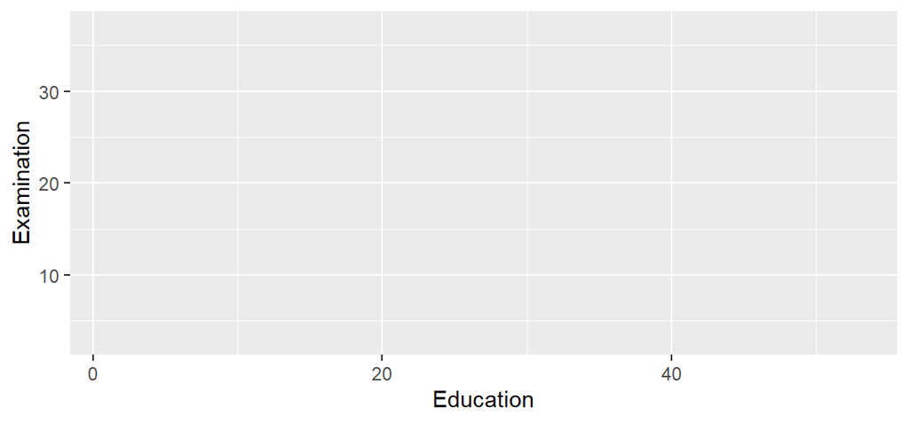

```r
ggplot(data = swiss, aes(x = Education, y = Examination))
```

## Geometries (~the type of plot)

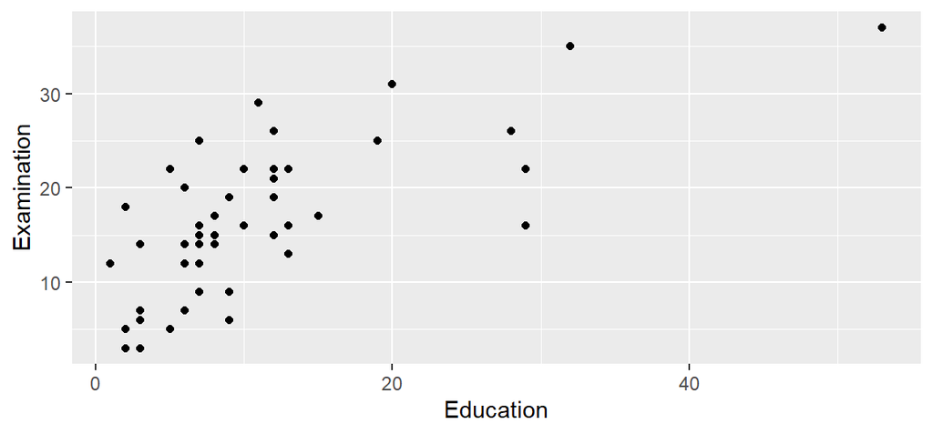

```r
ggplot(data = swiss, aes(x = Education, y = Examination)) +
     geom_point()
```

## Facets

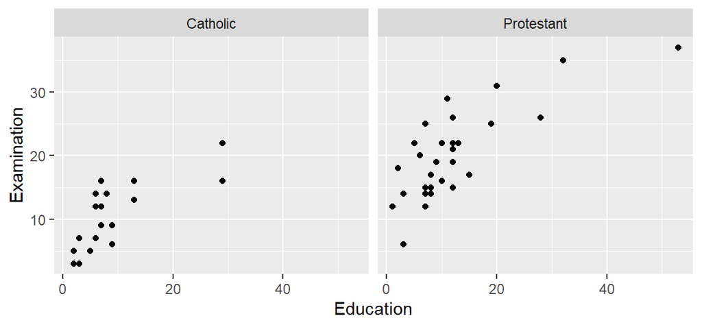

```r
ggplot(data = swiss, aes(x = Education, y = Examination)) +
     geom_point() +
     facet_wrap(~Religion)
```

## Additional layers and statistics

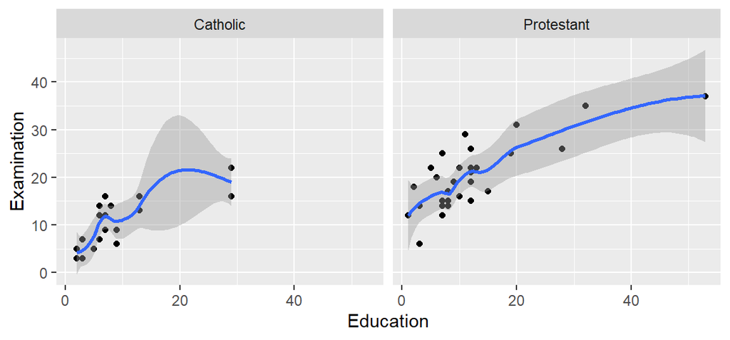

```r
ggplot(data = swiss, aes(x = Education, y = Examination)) +
     geom_point() +
     geom_smooth(method = 'loess') +
     facet_wrap(~Religion)
```

## Additional layers and statistics

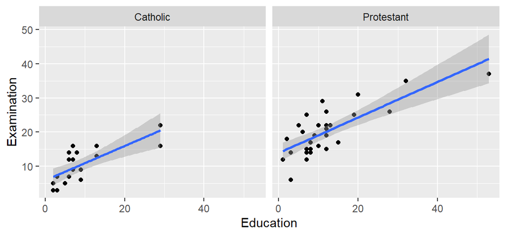

```r
ggplot(data = swiss, aes(x = Education, y = Examination)) +
     geom_point() +
     geom_smooth(method = 'lm') +
     facet_wrap(~Religion)
```

## Additional aesthetics

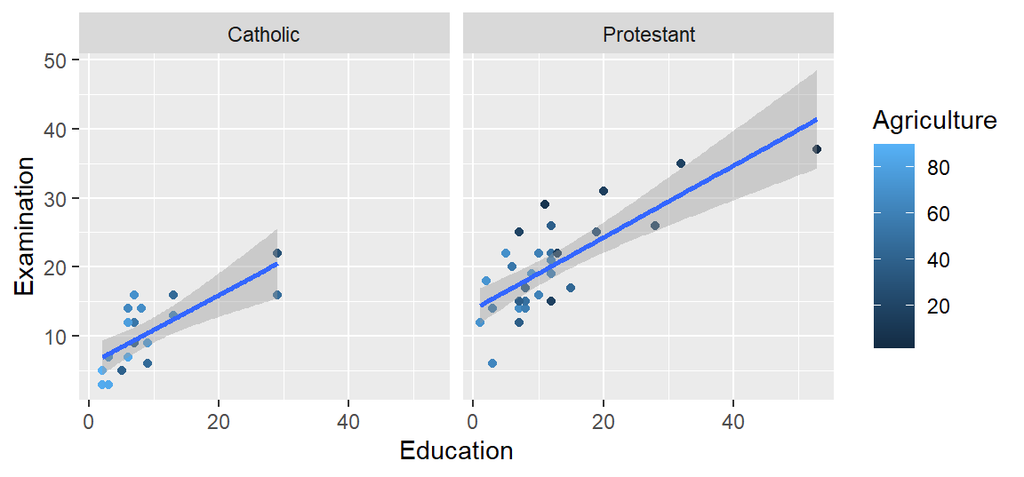

```r
ggplot(data = swiss, aes(x = Education, y = Examination)) +
     geom_point(aes(color = Agriculture)) +
     geom_smooth(method = 'lm') +
     facet_wrap(~Religion)
```

## Change coordinates

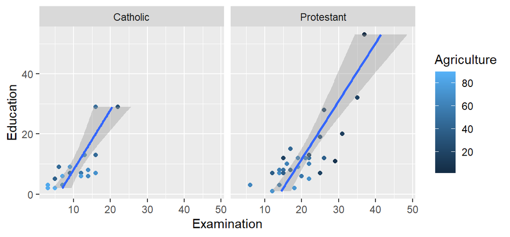

```r
ggplot(data = swiss, aes(x = Education, y = Examination)) +
     geom_point(aes(color = Agriculture)) +
     geom_smooth(method = 'lm') +
     facet_wrap(~Religion) +
     coord_flip()
```

## Themes

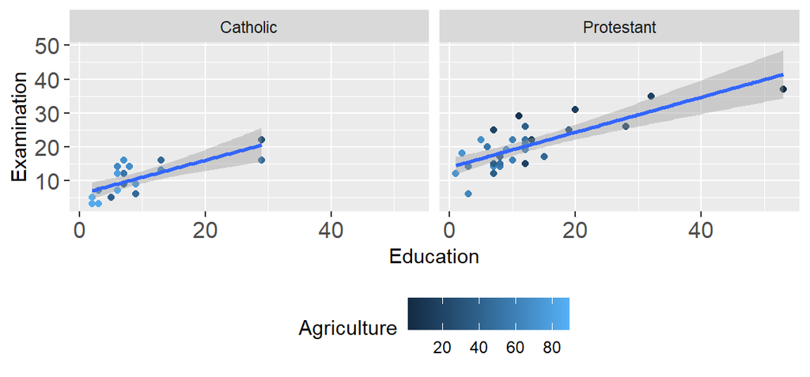

```r
ggplot(data = swiss, aes(x = Education, y = Examination)) +
     geom_point(aes(color = Agriculture)) +
     geom_smooth(method = 'lm') +
     facet_wrap(~Religion) +
     theme(legend.position = "bottom", axis.text=element_text(size=12) )
```

## Themes

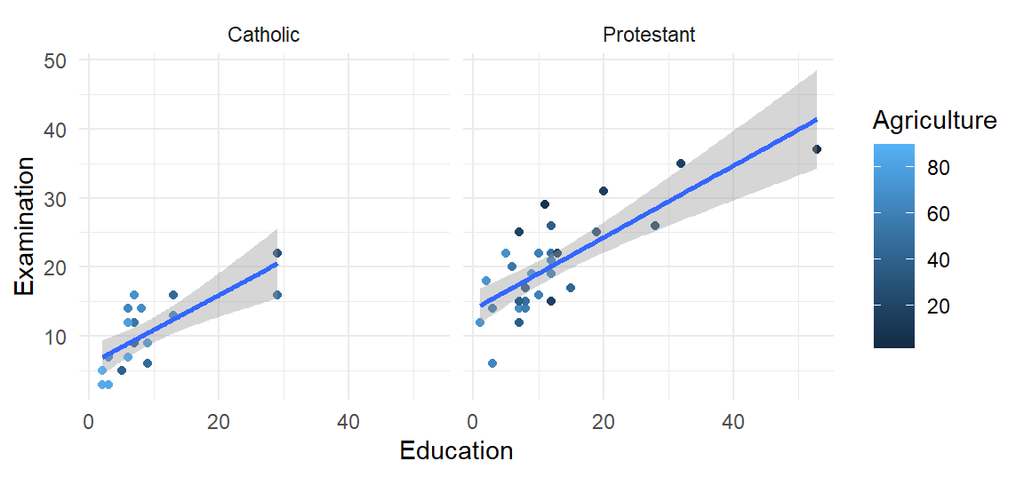

```r
ggplot(data = swiss, aes(x = Education, y = Examination)) +
     geom_point(aes(color = Agriculture)) +
     geom_smooth(method = 'lm') +
     facet_wrap(~Religion) +
     theme_minimal()
```

## Themes

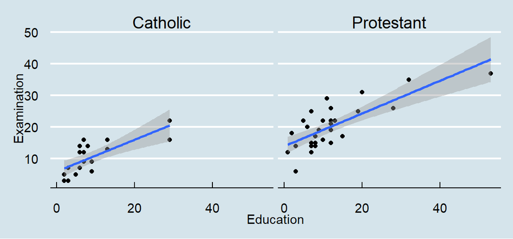

```r
library(ggthemes)

ggplot(data = swiss, aes(x = Education, y = Examination)) +
     geom_point() +
     geom_smooth(method = 'lm') +
     facet_wrap(~Religion) +
     theme_economist()
```

## Cheat sheet

[figure not shown]

Link: https://rstudio.github.io/cheatsheets/html/data-visualization.html

## Data visualization

- Values are represented by their *position relative to the axes*: line charts and scatterplots.
- Values are represented by the *size of an area*: bar charts and area charts.
- Values are *continuous*: use chart type that visually connects elements (line chart).
- Values are *categorical*: use chart type that visually separates elements (bar chart).

(Source: https://hhsievertsen.github.io/EconDataBook/data-visualization-basics.html)

## Data visualization: some principles

- Two pieces of advice I personally received:
  - *fit your whole story in one graph*.
  - your audience should understand your graph *without the need of listening to you* or *reading your text.*
- Be simple and avoid fanciness.
- Avoid pie charts and 3D charts.

## Data visualization: some principles

Recommendations from Tufte

[figure not shown]

## Data visualization: some principles

We can quantify the Lie Factor of a graph

Lie Factor = \(\frac{\text{size of effect shown in graphic}}{\text{size of effect in data}}\)

[figure not shown]

## Thou shalt not truncate the Y axis.

[figure not shown]

## Data visualization: some principles

Only what matters should be reported (*Data-ink Ratio*):

Data-ink Ratio = \(\frac{\text{ink used for data}}{\text{total ink used to print the graphic }}\)

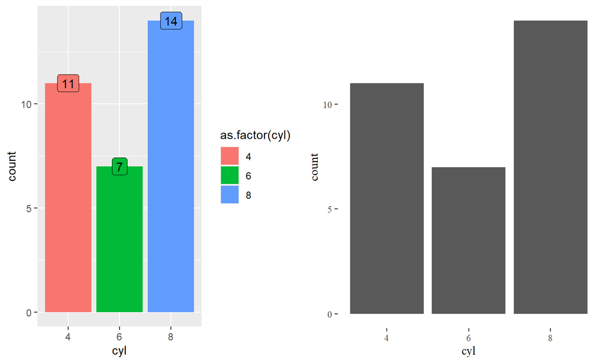

## Conclusion

Data visualization is an art of story-telling, deception, and scientific exactitude 🤓.

## Q&A

## References

R Core Team. 2018. *R: A Language and Environment for Statistical Computing*. Vienna, Austria: R Foundation for Statistical Computing. https://www.R-project.org/.

Sarkar, Deepayan. 2008. *Lattice: Multivariate Data Visualization with r*. New York: Springer. http://lmdvr.r-forge.r-project.org.

Wickham, Hadley. 2016. *Ggplot2: Elegant Graphics for Data Analysis*. Springer-Verlag New York. http://ggplot2.org.